# Exploratory Period Tutorial #7

2021-07-09

```r
library(plotly)
library(reshape)
library(GGally)
library(shinycssloaders)
library(shiny)
library(ggplot2)
library(forecast)
library(e1071)
library(neuralnet)
```

Knowledge can be defined as “knowing what to do.” A data scientist converts information, extracted by a data analyst, into knowledge, by using data modeling tools such as mathematical modeling and machine learning. We have discussed three machine learning techniques in this exploratory period: Linear Regression, SVR, and ANN. It is now time to apply the complete data modeling process to PRECON data on selected houses for STLF.

```r
Houses <- read.csv("Houses.csv")

Houses$Date_Time = as.POSIXct(Houses$Date_Time)
```

After isolating the **House26** hourly data, we should investigate the Auto-correlation function (ACF) as we are trying to use Autocorrelation to forecast the load. [Here](https://online.stat.psu.edu/stat462/node/188/) is a good article on this Autocorrelation.

```r
Houses$X <- NULL

House26 <- Houses[,c(1,7)]
colnames(House26) = c("Time", "hourly_load")
```

Our data is highly seasonal, and the [seasonaliity](https://en.wikipedia.org/wiki/Seasonality) spans a day. See the ACF plot below. The hourly load is highly correlated with the historical data, especially the previous hour, day, and week.

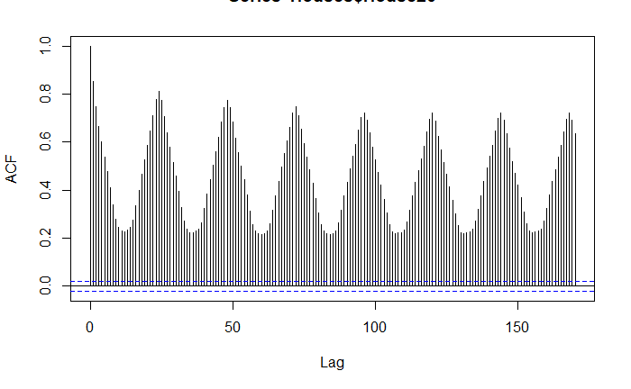

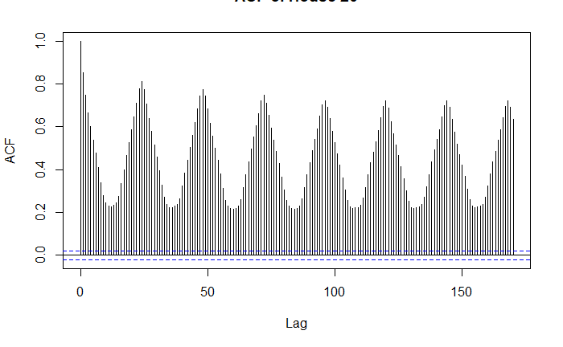

```r
  plot(acf(Houses$House26, lag.max = 170), main = "ACF of House 26")
```

```r
NA
NA
```

Let’s create a column of hourly, daily, and weekly lags for further investigation.

```r
## This code creates extra rows for 1st June, 2019, the day we want to forecast for.

House26 <- rbind(House26,data.frame(Time = rep(NA, 24),
                                   hourly_load =rep(NA,24)))

House26$Time <- seq.POSIXt(from = as.POSIXct("2018-06-01 00:00:00 PKT"),
                                  to = as.POSIXct("2019-06-01 23:00:00 PKT"), by = "hour")
```

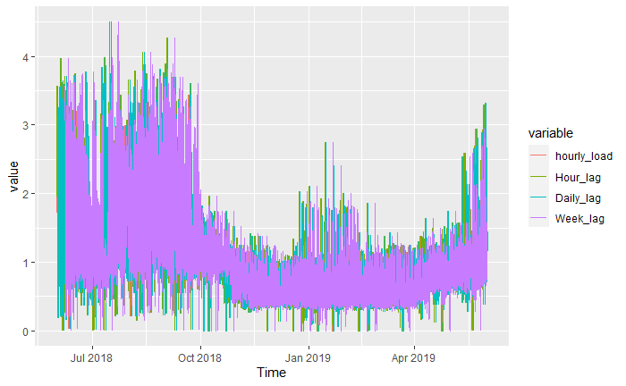

```r
House26$Hour_lag = c(rep(NA,1),House26$hourly_load[1:(nrow(House26)-1)])

House26$Daily_lag = c(rep(NA,24),House26$hourly_load[1:(nrow(House26)-24)])

House26$Week_lag = c(rep(NA,168),House26$hourly_load[1:(nrow(House26)-168)])



house26_plot =  melt(House26[,-1])

house26_plot$Time = House26$Time


ggplot(house26_plot, aes(x = Time))+
  geom_line(aes(y = value, color = variable))
```

```r
NA
NA
NA
NA
```

A more useful set of plots are shown below. There is a high correlation between *hourly_load* and the rest of the independent variables. *Hour_lag* has the highest correlation of 0.853 with the *hourly_load*. But this also shows a problem, Multicollinearity. :(

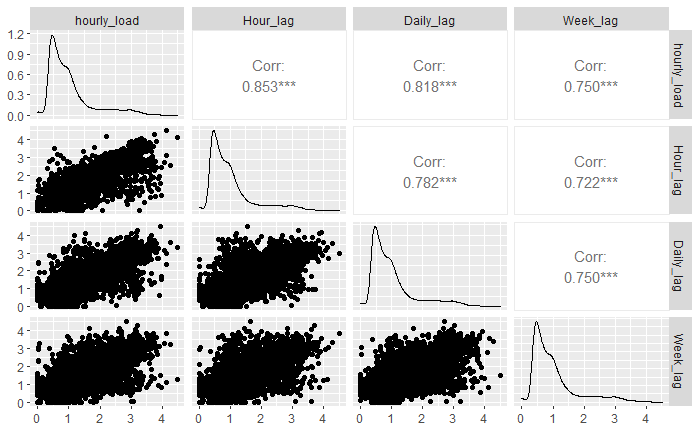

```r
ggpairs(House26[,-1])
```

```r
NA
NA
NA
NA
NA
NA
```

```r
renderTable({

  House26_table = House26[(nrow(House26)-23): nrow(House26),]

  House26_table$Time <- strftime(House26_table$Time, format="%Y-%m-%d %H:%M:%S")

  House26_table

})
```

```
<shiny.render.function>
```

*Create Linear Regression, SVR and ANN models using Daily_lag as the independent variable for each of the 10 Houses.*

*Create Linear Regression, SVR and ANN models using Weekly_lag as the independent variable for each of the 10 Houses.*

*Forecast 1st June 2019 load using both sets of models for each household. Send me the results in a single CSV file.*

*Create a complete report showing all your work.*